# 02_intervals_check

## 02_intervals_check

#### Question

1. The graph of $y=f(x)$ is shown below.

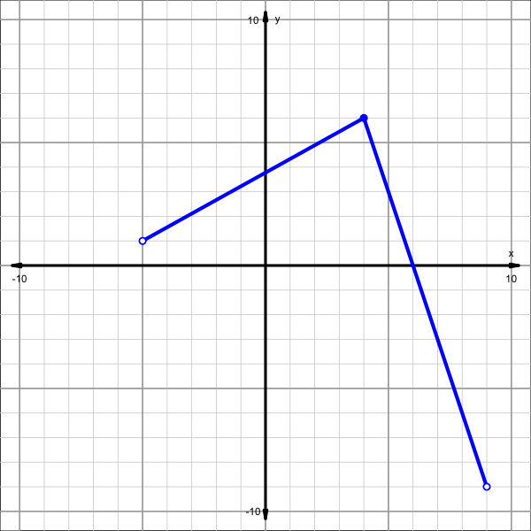

   Using interval notation, indicate the following:
   1. For what values of $x$ is the function’s output positive? (Where is $f(x)>0$?)
   - (, )
   2. For what values of $x$ is the function’s output negative? (Where is $f(x)<0$?)
   - (, )
   3. For what values of $x$ is the function increasing?
   - (, )
   4. For what values of $x$ is the function decreasing?
   - (, )
   5. What is the domain of $f$? (For what values of $x$ does $f$ exist?)
   - (, )
   6. What is the range of $f$? (For what values of $y$ does $f$ exist?)
   - (, ]

   Now, using a [Cartesian coordinate](https://en.wikipedia.org/wiki/Cartesian_coordinate_system), indicate the location of the local maximum.
   7. The location of the local maximum is (, ).

#### Question

2. The graph of $y=f(x)$ is shown below.

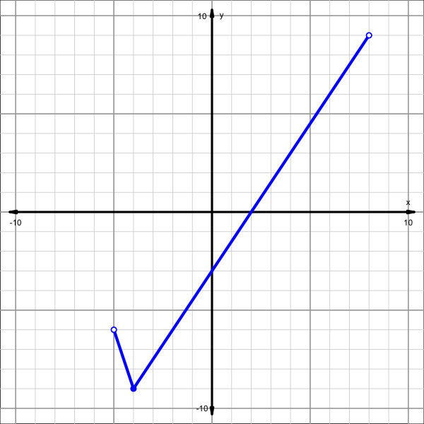

   Using interval notation, indicate the following:
   1. For what values of $x$ is the function’s output positive? (Where is $f(x)>0$?)
   - (, )
   2. For what values of $x$ is the function’s output negative? (Where is $f(x)<0$?)
   - (, )
   3. For what values of $x$ is the function increasing?
   - (, )
   4. For what values of $x$ is the function decreasing?
   - (, )
   5. What is the domain of $f$? (For what values of $x$ does $f$ exist?)
   - (, )
   6. What is the range of $f$? (For what values of $y$ does $f$ exist?)
   - [, )

   Now, using a [Cartesian coordinate](https://en.wikipedia.org/wiki/Cartesian_coordinate_system), indicate the location of the local minimum.
   7. The location of the local minimum is (, ).

#### Question

3. The graph of $y=f(x)$ is shown below.

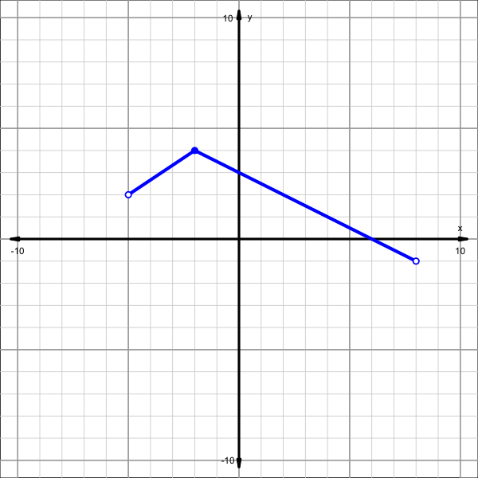

   Using interval notation, indicate the following:
   1. For what values of $x$ is the function’s output positive? (Where is $f(x)>0$?)
   - (, )
   2. For what values of $x$ is the function’s output negative? (Where is $f(x)<0$?)
   - (, )
   3. For what values of $x$ is the function increasing?
   - (, )
   4. For what values of $x$ is the function decreasing?
   - (, )
   5. What is the domain of $f$? (For what values of $x$ does $f$ exist?)
   - (, )
   6. What is the range of $f$? (For what values of $y$ does $f$ exist?)
   - (, ]

   Now, using a [Cartesian coordinate](https://en.wikipedia.org/wiki/Cartesian_coordinate_system), indicate the location of the local maximum.
   7. The location of the local maximum is (, ).

#### Question

4. The graph of $y=f(x)$ is shown below.

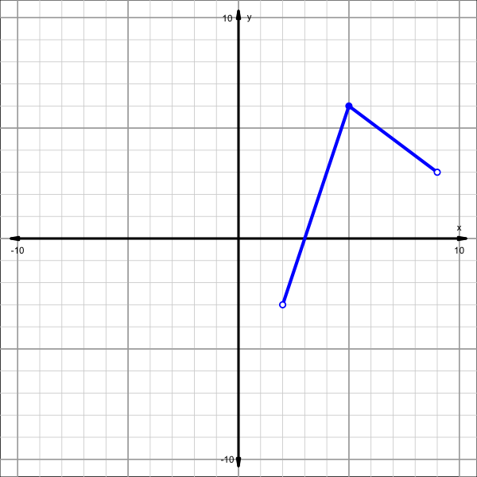

   Using interval notation, indicate the following:
   1. For what values of $x$ is the function’s output positive? (Where is $f(x)>0$?)
   - (, )
   2. For what values of $x$ is the function’s output negative? (Where is $f(x)<0$?)
   - (, )
   3. For what values of $x$ is the function increasing?
   - (, )
   4. For what values of $x$ is the function decreasing?
   - (, )
   5. What is the domain of $f$? (For what values of $x$ does $f$ exist?)
   - (, )
   6. What is the range of $f$? (For what values of $y$ does $f$ exist?)
   - (, ]

   Now, using a [Cartesian coordinate](https://en.wikipedia.org/wiki/Cartesian_coordinate_system), indicate the location of the local maximum.
   7. The location of the local maximum is (, ).

#### Question

5. The graph of $y=f(x)$ is shown below.

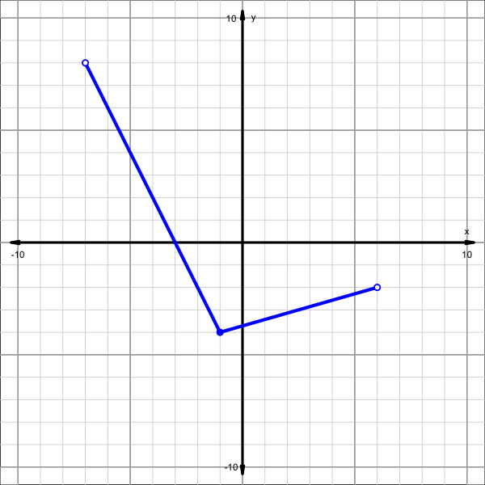

   Using interval notation, indicate the following:
   1. For what values of $x$ is the function’s output positive? (Where is $f(x)>0$?)
   - (, )
   2. For what values of $x$ is the function’s output negative? (Where is $f(x)<0$?)
   - (, )
   3. For what values of $x$ is the function increasing?
   - (, )
   4. For what values of $x$ is the function decreasing?
   - (, )
   5. What is the domain of $f$? (For what values of $x$ does $f$ exist?)
   - (, )
   6. What is the range of $f$? (For what values of $y$ does $f$ exist?)
   - [, )

   Now, using a [Cartesian coordinate](https://en.wikipedia.org/wiki/Cartesian_coordinate_system), indicate the location of the local minimum.
   7. The location of the local minimum is (, ).

#### Question

6. The graph of $y=f(x)$ is shown below.

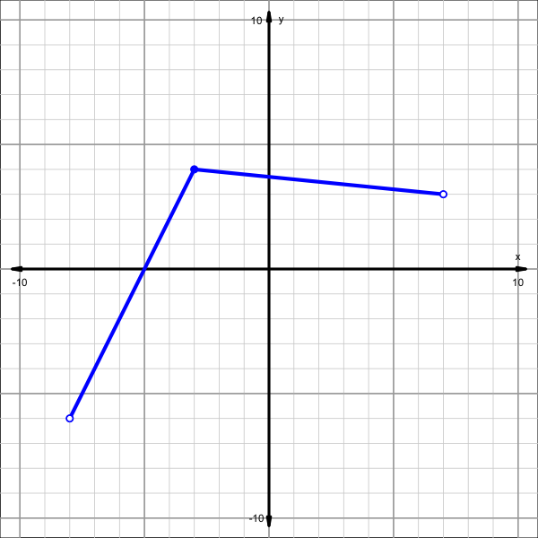

   Using interval notation, indicate the following:
   1. For what values of $x$ is the function’s output positive? (Where is $f(x)>0$?)
   - (, )
   2. For what values of $x$ is the function’s output negative? (Where is $f(x)<0$?)
   - (, )
   3. For what values of $x$ is the function increasing?
   - (, )
   4. For what values of $x$ is the function decreasing?
   - (, )
   5. What is the domain of $f$? (For what values of $x$ does $f$ exist?)
   - (, )
   6. What is the range of $f$? (For what values of $y$ does $f$ exist?)
   - (, ]

   Now, using a [Cartesian coordinate](https://en.wikipedia.org/wiki/Cartesian_coordinate_system), indicate the location of the local maximum.
   7. The location of the local maximum is (, ).

#### Question

7. The graph of $y=f(x)$ is shown below.

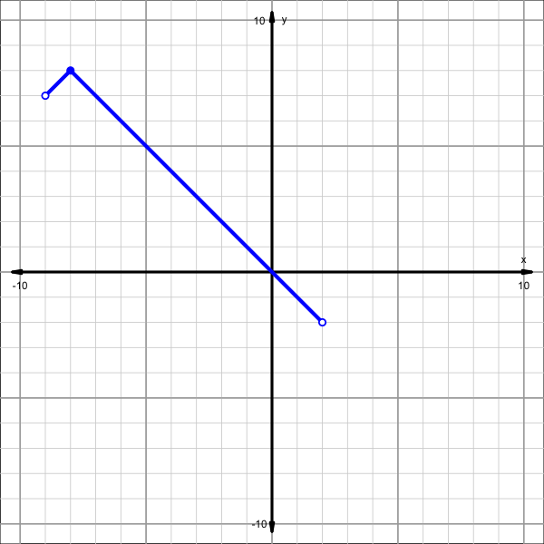

   Using interval notation, indicate the following:
   1. For what values of $x$ is the function’s output positive? (Where is $f(x)>0$?)
   - (, )
   2. For what values of $x$ is the function’s output negative? (Where is $f(x)<0$?)
   - (, )
   3. For what values of $x$ is the function increasing?
   - (, )
   4. For what values of $x$ is the function decreasing?
   - (, )
   5. What is the domain of $f$? (For what values of $x$ does $f$ exist?)
   - (, )
   6. What is the range of $f$? (For what values of $y$ does $f$ exist?)
   - (, ]

   Now, using a [Cartesian coordinate](https://en.wikipedia.org/wiki/Cartesian_coordinate_system), indicate the location of the local maximum.
   7. The location of the local maximum is (, ).

#### Question

8. The graph of $y=f(x)$ is shown below.

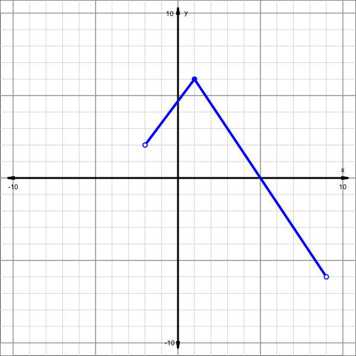

   Using interval notation, indicate the following:
   1. For what values of $x$ is the function’s output positive? (Where is $f(x)>0$?)
   - (, )
   2. For what values of $x$ is the function’s output negative? (Where is $f(x)<0$?)
   - (, )
   3. For what values of $x$ is the function increasing?
   - (, )
   4. For what values of $x$ is the function decreasing?
   - (, )
   5. What is the domain of $f$? (For what values of $x$ does $f$ exist?)
   - (, )
   6. What is the range of $f$? (For what values of $y$ does $f$ exist?)
   - (, ]

   Now, using a [Cartesian coordinate](https://en.wikipedia.org/wiki/Cartesian_coordinate_system), indicate the location of the local maximum.
   7. The location of the local maximum is (, ).

#### Question

9. The graph of $y=f(x)$ is shown below.

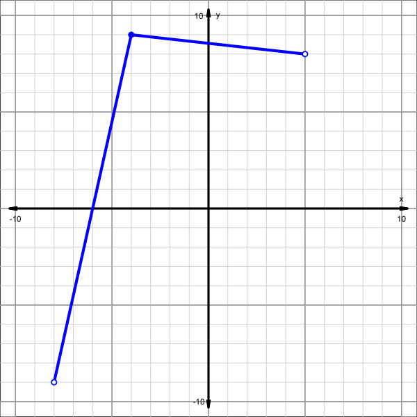

   Using interval notation, indicate the following:
   1. For what values of $x$ is the function’s output positive? (Where is $f(x)>0$?)
   - (, )
   2. For what values of $x$ is the function’s output negative? (Where is $f(x)<0$?)
   - (, )
   3. For what values of $x$ is the function increasing?
   - (, )
   4. For what values of $x$ is the function decreasing?
   - (, )
   5. What is the domain of $f$? (For what values of $x$ does $f$ exist?)
   - (, )
   6. What is the range of $f$? (For what values of $y$ does $f$ exist?)
   - (, ]

   Now, using a [Cartesian coordinate](https://en.wikipedia.org/wiki/Cartesian_coordinate_system), indicate the location of the local maximum.
   7. The location of the local maximum is (, ).

#### Question

10. The graph of $y=f(x)$ is shown below.

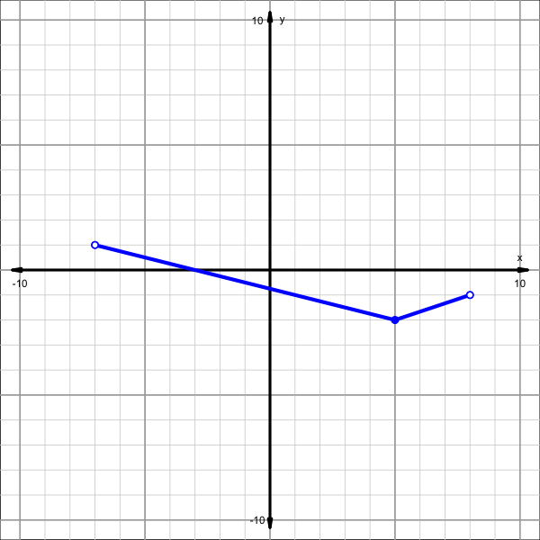

    Using interval notation, indicate the following:
    1. For what values of $x$ is the function’s output positive? (Where is $f(x)>0$?)
    - (, )
    2. For what values of $x$ is the function’s output negative? (Where is $f(x)<0$?)
    - (, )
    3. For what values of $x$ is the function increasing?
    - (, )
    4. For what values of $x$ is the function decreasing?
    - (, )
    5. What is the domain of $f$? (For what values of $x$ does $f$ exist?)
    - (, )
    6. What is the range of $f$? (For what values of $y$ does $f$ exist?)
    - [, )

    Now, using a [Cartesian coordinate](https://en.wikipedia.org/wiki/Cartesian_coordinate_system), indicate the location of the local minimum.
    7. The location of the local minimum is (, ).

#### Question

11. The graph of $y=f(x)$ is shown below.

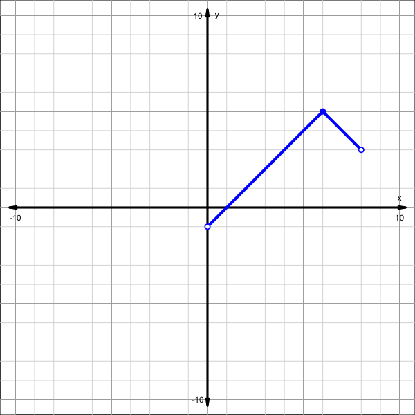

    Using interval notation, indicate the following:
    1. For what values of $x$ is the function’s output positive? (Where is $f(x)>0$?)
    - (, )
    2. For what values of $x$ is the function’s output negative? (Where is $f(x)<0$?)
    - (, )
    3. For what values of $x$ is the function increasing?
    - (, )
    4. For what values of $x$ is the function decreasing?
    - (, )
    5. What is the domain of $f$? (For what values of $x$ does $f$ exist?)
    - (, )
    6. What is the range of $f$? (For what values of $y$ does $f$ exist?)
    - (, ]

    Now, using a [Cartesian coordinate](https://en.wikipedia.org/wiki/Cartesian_coordinate_system), indicate the location of the local maximum.
    7. The location of the local maximum is (, ).

#### Question

12. The graph of $y=f(x)$ is shown below.

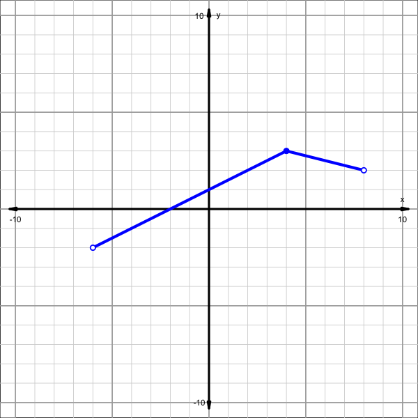

    Using interval notation, indicate the following:
    1. For what values of $x$ is the function’s output positive? (Where is $f(x)>0$?)
    - (, )
    2. For what values of $x$ is the function’s output negative? (Where is $f(x)<0$?)
    - (, )
    3. For what values of $x$ is the function increasing?
    - (, )
    4. For what values of $x$ is the function decreasing?
    - (, )
    5. What is the domain of $f$? (For what values of $x$ does $f$ exist?)
    - (, )
    6. What is the range of $f$? (For what values of $y$ does $f$ exist?)
    - (, ]

    Now, using a [Cartesian coordinate](https://en.wikipedia.org/wiki/Cartesian_coordinate_system), indicate the location of the local maximum.
    7. The location of the local maximum is (, ).